# Visualization

# Base Plotting (Stone Age)

```r
library(raw)    # R Actuarial Workshop
data("RegionExperience")

head(RegionExperience, 3)
```

```
##          Region PolicyYear NumPolicies NumClaims
## 1 North Central       2001         579      4285
## 2 North Central       2002         585      4459
## 3 North Central       2003         588      4312
```

```r
summary(RegionExperience)
```

```
##            Region     PolicyYear    NumPolicies      NumClaims
##  North Central:10   Min.   :2001   Min.   :381.0   Min.   :3183
##  Northeast    :10   1st Qu.:2003   1st Qu.:480.8   1st Qu.:3599
##  South        :10   Median :2006   Median :567.5   Median :4069
##  West         :10   Mean   :2006   Mean   :567.5   Mean   :4964
##                     3rd Qu.:2008   3rd Qu.:636.2   3rd Qu.:5376
##                     Max.   :2010   Max.   :804.0   Max.   :9088
```

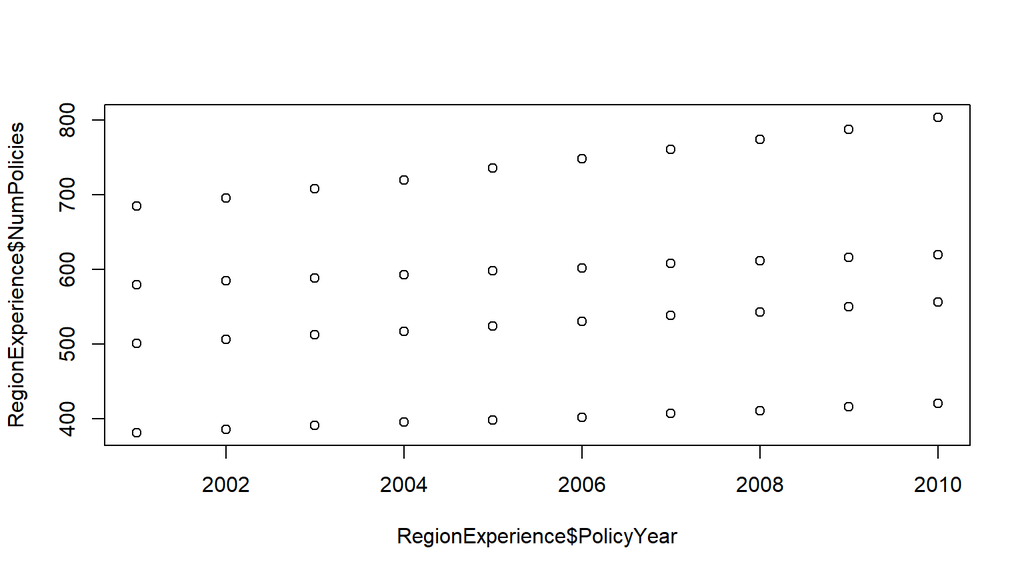

```r
# basic plot
plot(x=RegionExperience$PolicyYear, y=RegionExperience$NumPolicies)
```

# Base Plotting

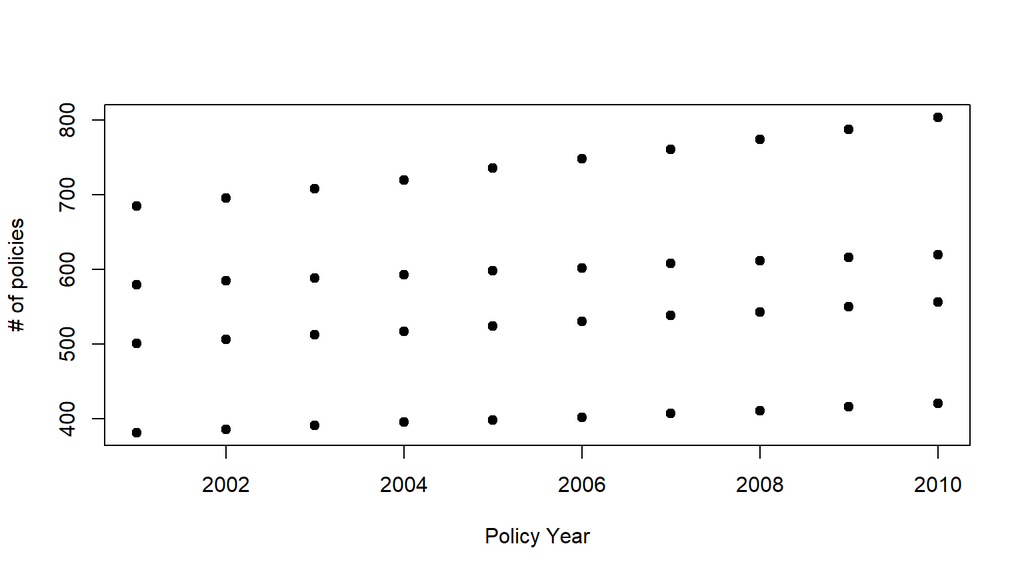

```r
# some more customization
# ex: pch affects how the "dot" looks
plot(x=RegionExperience$PolicyYear, y=RegionExperience$NumPolicies,
     pch = 19, xlab = 'Policy Year', ylab = '# of policies')
```

# Base Plotting

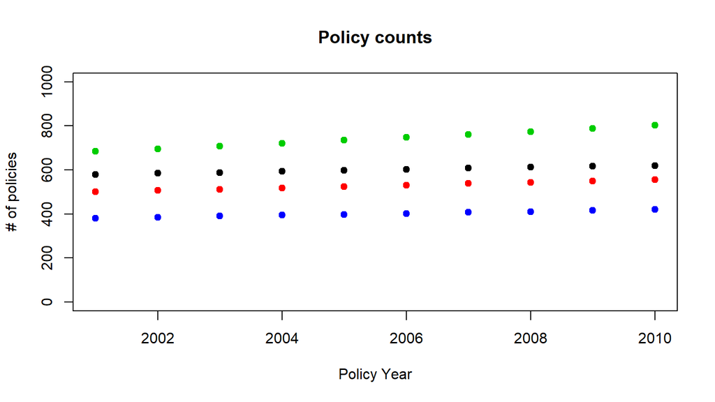

```r
# some more customization
plot(x=RegionExperience$PolicyYear, y=RegionExperience$NumPolicies,
     col = RegionExperience$Region,
     pch = 19, xlab = 'Policy Year', ylab = '# of policies',
     main = 'Policy counts', ylim=c(0, 1000))
```

# Base Plotting

- Kinda ugly
- Customization is possible, but tedious

# ggplot (Iron Age)

gg = “grammar of graphics” based on Leland Wilkinson

1. Data
2. Mapping
3. Layers
4. Scales
5. Facets
6. Non-data Visual Elements

# ggplot - Data

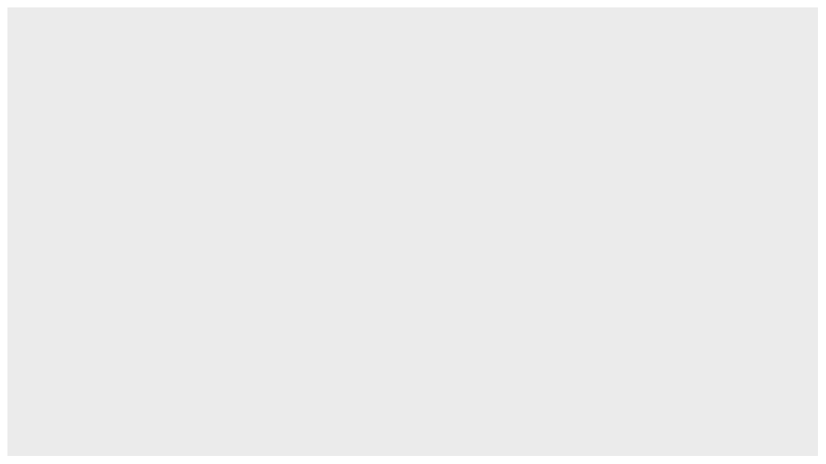

```r
library(ggplot2)
library(dplyr)

# initialize ggplot() object
plt_base <- ggplot(data=RegionExperience)
plt_base # blank plot
```

# ggplot - Data

Data loaded into ggplot() must be a data frame.

```r
ggplot(1:10)
```

```
## Error: `data` must be a data frame, or other object coercible by `fortify()`, not an integer vector
```

```r
data(COTOR2)
class(COTOR2)
```

```
## [1] "numeric"
```

```r
ggplot(COTOR2)
```

```
## Error: `data` must be a data frame, or other object coercible by `fortify()`, not a numeric vector
```

# ggplot - Mapping

Mappings bind data to visual elements. Every data-derived visual element must be mapped to data.

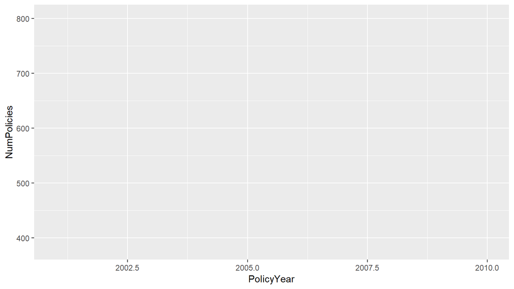

```r
# aes = aesthetic mapping
plt_base <- plt_base + aes(x=PolicyYear, y=NumPolicies)
plt_base
```

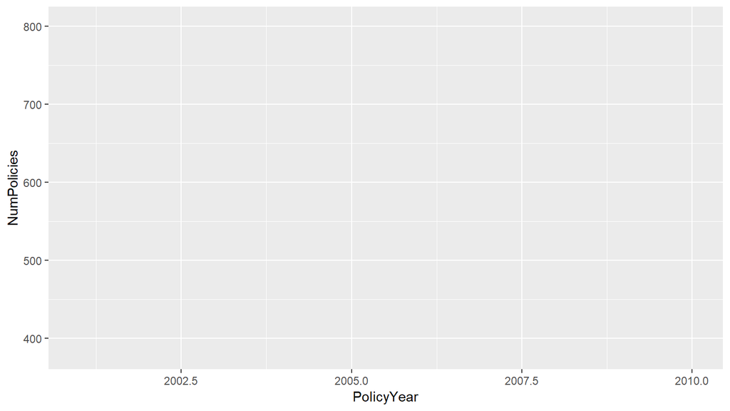

```r
# another way of adding a mapping
plt_base <- ggplot(data=RegionExperience,
                   mapping=aes(x=PolicyYear, y=NumPolicies))
plt_base
```

# ggplot - Layers

Adding layers

Although we have data and we’ve mapped to elements of a coordinate system, we haven’t specified what the visual elements should be. The `geom_*` family of functions adds geometric shapes.

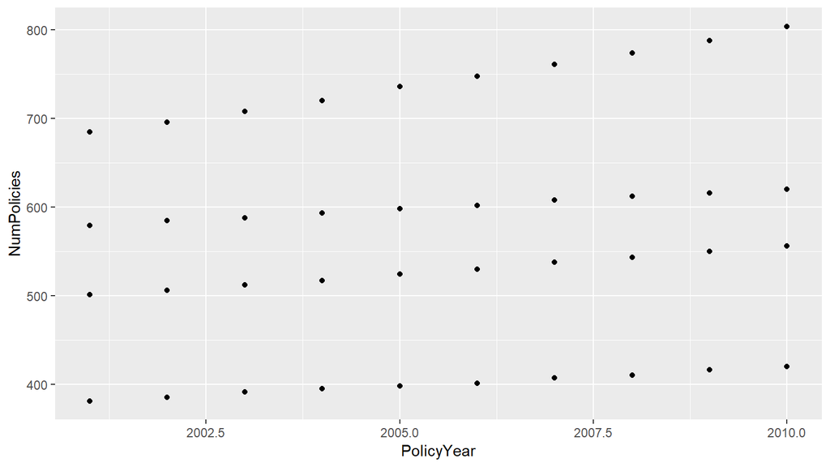

```r
plt_base <- plt_base + geom_point()
plt_base
```

Let’s do everything in one step now

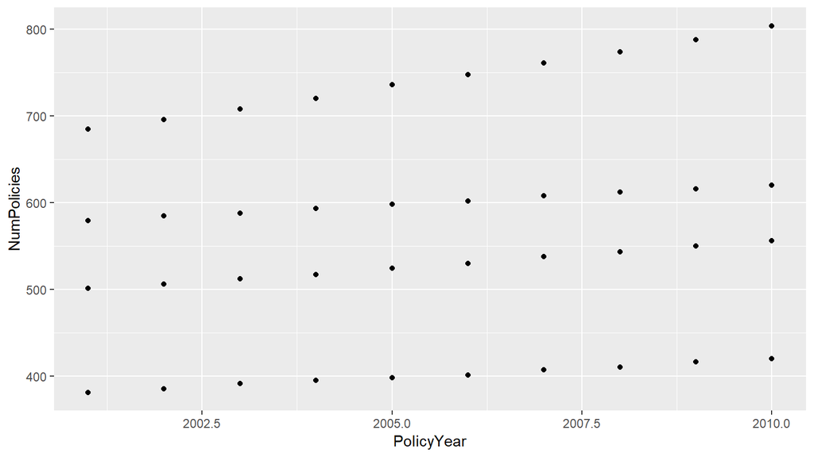

```r
# dataset on left of pipe operator can be used
# on the right of pipe operator without referencing the dataset
RegionExperience %>%
  ggplot(aes(x=PolicyYear, y=NumPolicies)) +
  geom_point()
```

# ggplot - Layers

Let’s add more layers by connecting the data points by a line.

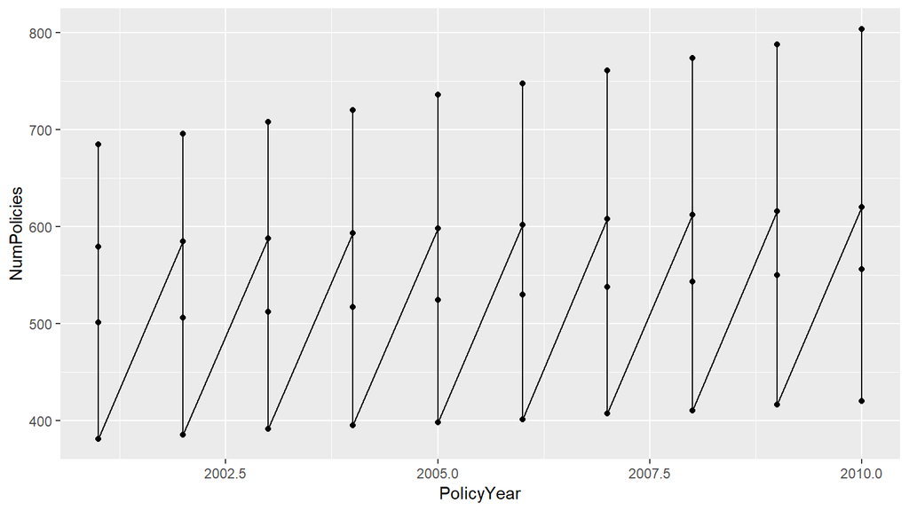

```r
RegionExperience %>%
  ggplot(aes(x=PolicyYear, y=NumPolicies)) +
  geom_point() +
  geom_line() # connect scatterplot with lines
```

That looks ugly because of the step differences in number of policies between different regions. Let’s try connecting the data points for each region by a line.

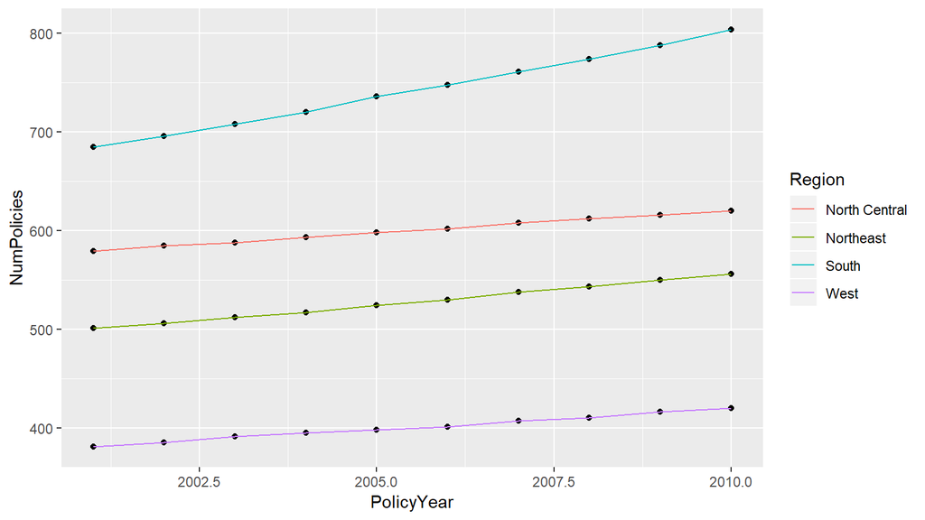

```r
RegionExperience %>%
  ggplot(aes(x=PolicyYear, y=NumPolicies)) +
  geom_point() +
  geom_line(aes(color=Region)) # we use color to map lines to regions
```

# ggplot - Layers

Let’s make the lines smoother by fitting a linear regression to the data points by region.

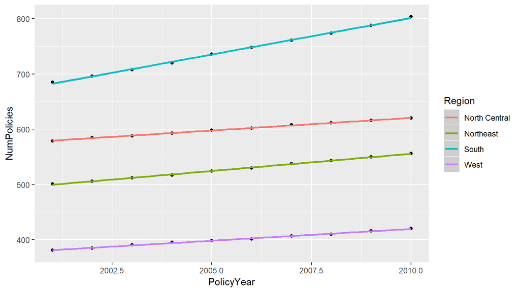

```r
RegionExperience %>%
  ggplot(aes(x=PolicyYear, y=NumPolicies)) +
  geom_point() +
  geom_smooth(method=lm, aes(color=Region))
```

# ggplot - Scales

Store a basic plot in an object

```r
plt <- RegionExperience %>%
  ggplot(aes(x=PolicyYear, y=NumPolicies)) +
  geom_point()
```

Change the y scale and labels

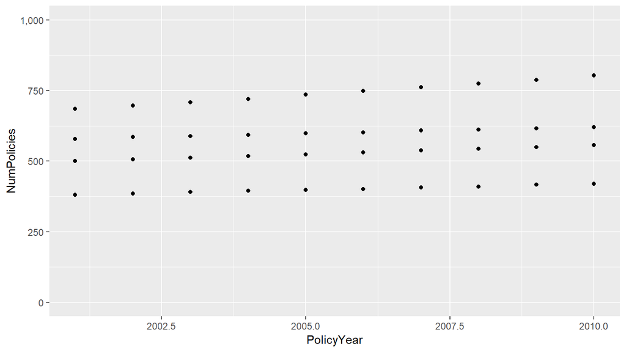

```r
plt + scale_y_continuous(limits = c(0,1000), labels = scales::comma)
```

Change the x breaks

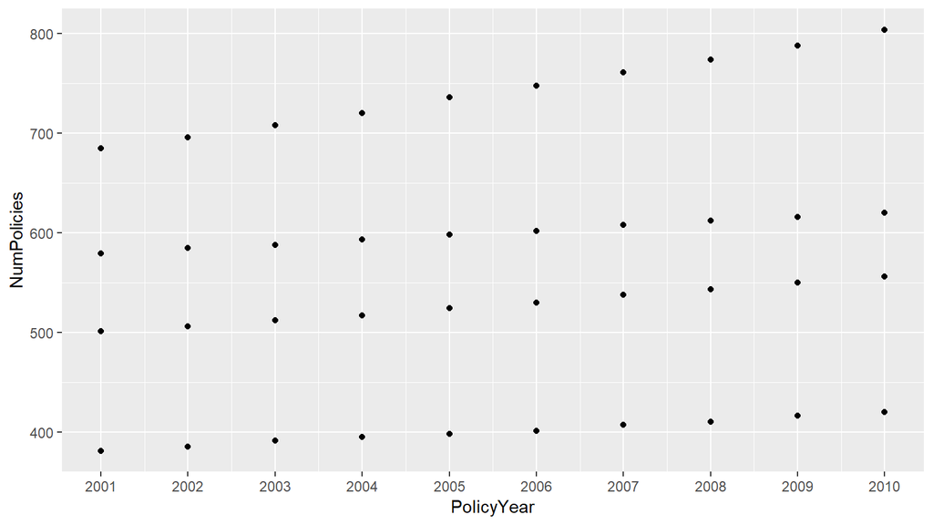

```r
plt + scale_x_continuous(breaks = 2001:2010)
```

Change the x breaks

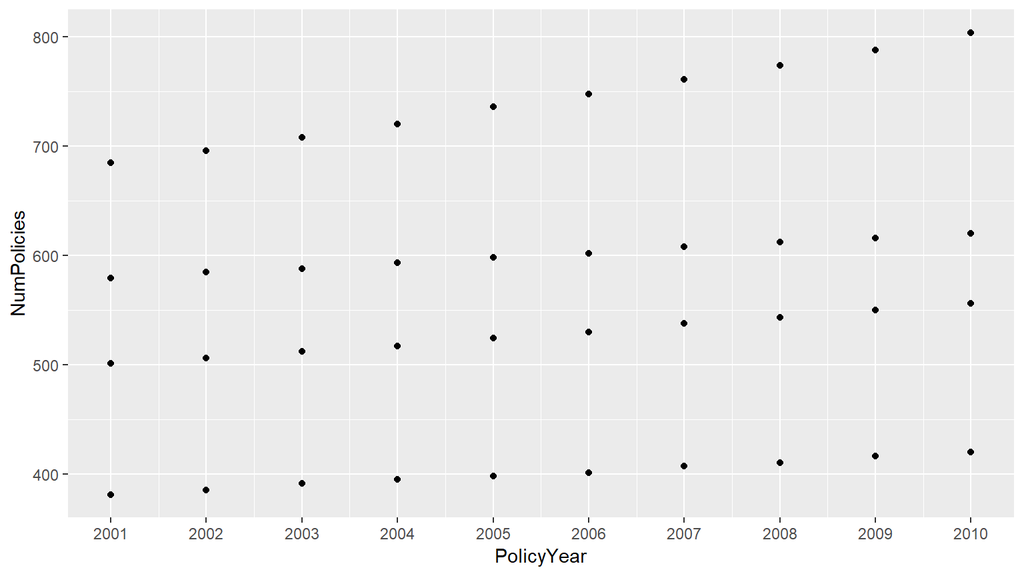

```r
my_breaks <- function(lims) {
  seq(ceiling(lims[1]), floor(lims[2]), by=1)
}
plt + scale_x_continuous(breaks=my_breaks)
```

# ggplot - Facets

Facets split the data into groups and draw a different plot for each group.

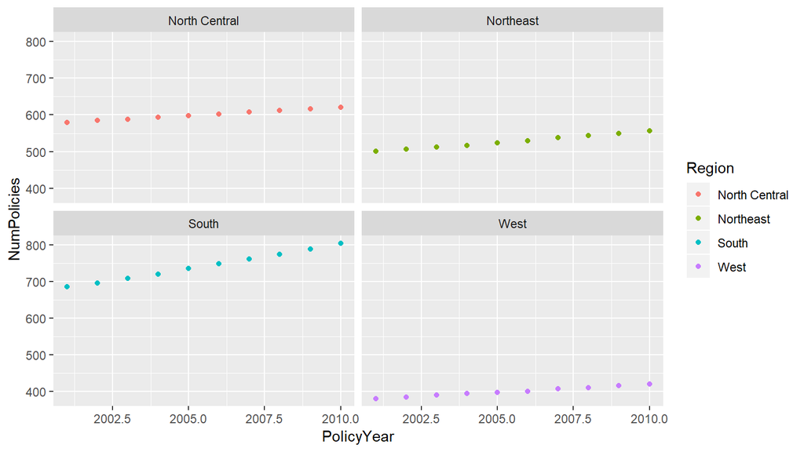

```r
RegionExperience %>%
  ggplot(aes(x=PolicyYear, y=NumPolicies, color=Region)) +
  geom_point() + facet_wrap(~Region)
```

# ggplot - Non-data visual elements

- labels
- gridlines
- legend
- axis ticks

# ggplot - Non-data visual elements

Labels

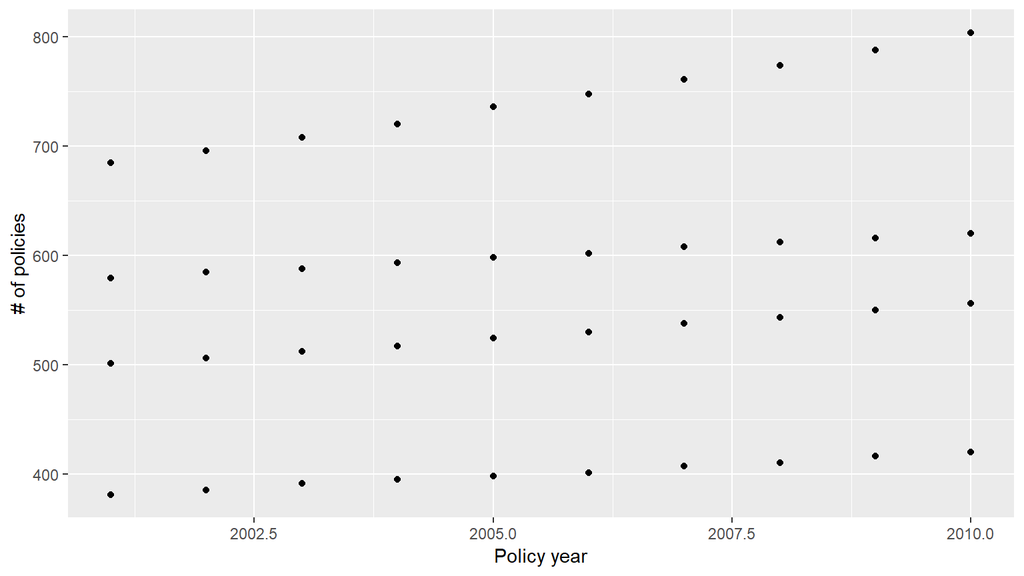

```r
plt + labs(x = 'Policy year', y = '# of policies')
```

Gridlines, legends, axis ticks

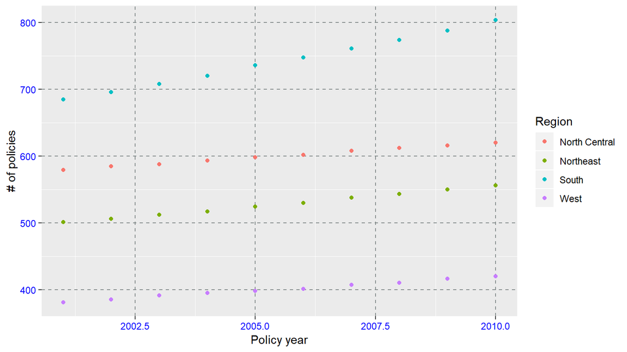

```r
plt + aes(color=Region) + labs(x = 'Policy year', y = '# of policies', color = "Region") +
   theme(panel.grid.major = element_line(colour = "azure4", linetype = "dashed")) +
   theme(axis.text = element_text(colour = "blue"))
```

# Stuff you can do with ggplot:

Line chart, bar chart, boxplot, scatterplots, dumbbell plot, violin plot, heatmaps, trellis plots, slopecharts, and more!

# Exercises

1. Create a scatter plot for policy year and number of claims.
2. Color each point based on region.
3. Add a linear smoother. Which region is showing the greatest increase in claims?
4. Form the policy frequency by taking the ratio of claims to policies. Plot this.

Extra credit:

Use the state data to create a time series number of claims. Facet by region.

# Solutions (1):

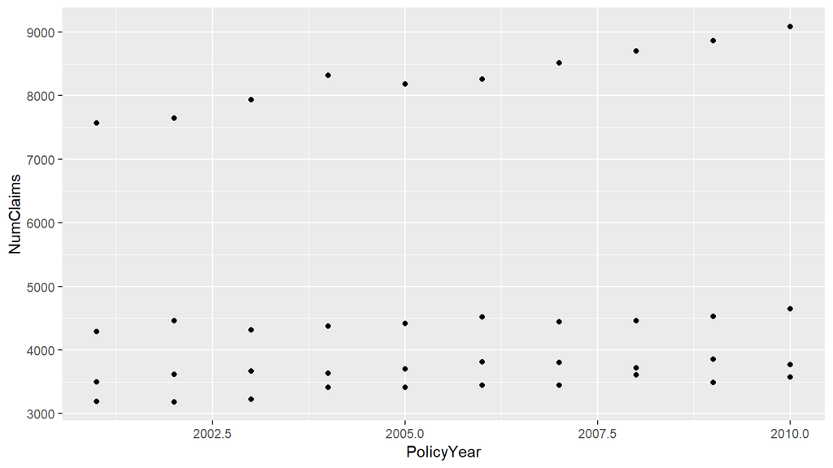

```r
library(raw)
data("RegionExperience")
plt1 <- ggplot(RegionExperience, aes(x = PolicyYear, y = NumClaims)) + geom_point()
plt1
```

# Solutions (2):

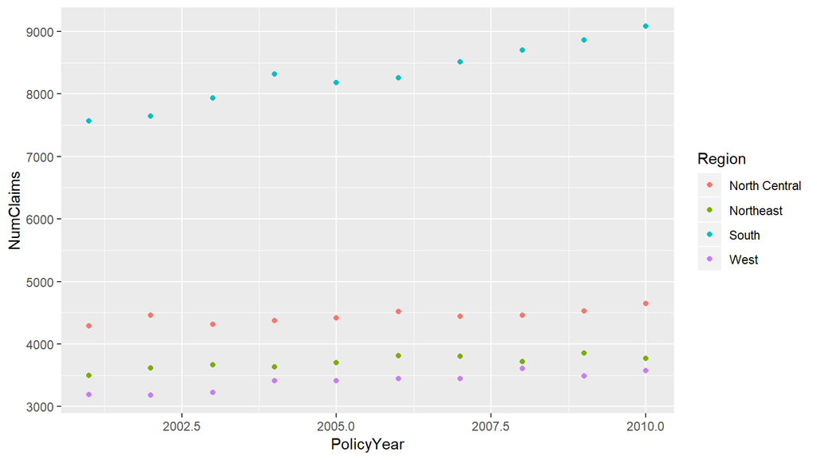

```r
plt2 <- plt1 + aes(color=Region)
plt2
```

# Solutions (3):

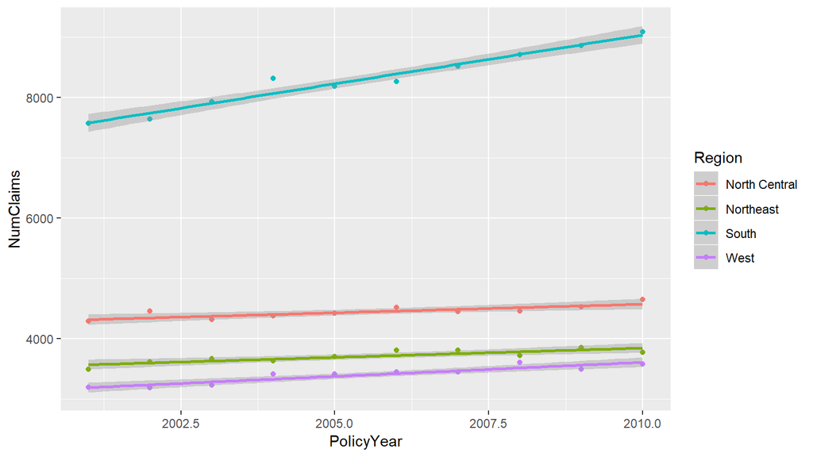

```r
plt3 <- plt2 + stat_smooth(method = "lm")
plt3
```

# Solutions (4):

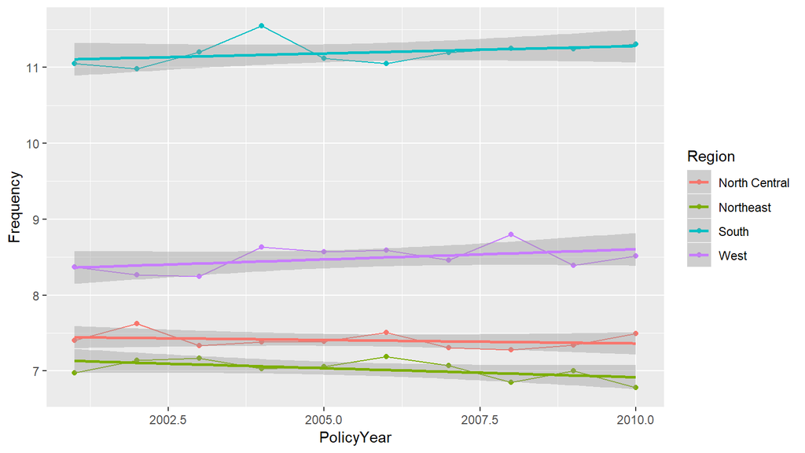

```r
RegionExperience$Frequency <- with(RegionExperience, NumClaims / NumPolicies)

plt4 <- ggplot(RegionExperience, aes(x=PolicyYear, y=Frequency, color=Region)) + geom_point()+
  geom_line() + stat_smooth(method=lm)
plt4
```

# Solutions (EC):

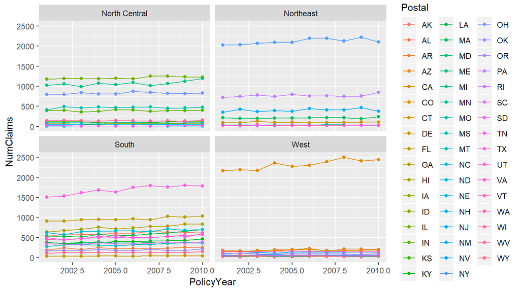

```r
data("StateExperience")
pltExtra <- ggplot(StateExperience, aes(x=PolicyYear, y=NumClaims, color=Postal)) +
   geom_point() + geom_line()
pltExtra + facet_wrap(~ Region)
```

# Summary

- `ggplot2` is different at first, but will repay your investment.
- Works very well with grouped data to color/facet points.
- Fine-tuning things like axis labels can be a headache, but will get easier.